# MIDS - w261 Machine Learning At Scale

### HW2.3.3 Learn a multinomial naive Bayes model (with no smoothing) for SPAM filtering

Systems test your code first with the Chinese Example and show the resulting model.

Learn a SPAM filtering model from the ENRON dataset provided above. Save the model to file SPAM_Model_MNB.tsv.

Show the top 10 terms alphabetically sortig the words increasing and their corresponding model entries. Write a mapreduce job to accomplish this. Show the bottom 10 terms also.

#### Systems test for the Chinese example is all done in 2.3.1 above.

```python
%%bash
#Run a mapreduce that includes the subject line.  Save the hadoop output to a regular file SPAM_Model_MNB.tsv
#Do a simple head and tail sort situation to show top 10 and bottom 10 terms alphabetically ordered
#Really this should be easy, it's just tweaking the mapper, running it, saving the model, then printing results

sudo touch NaiveBayes/mapper233.py
sudo touch NaiveBayes/reducer233.py
sudo chmod -R 777 NaiveBayes/
```

```python
%%writefile NaiveBayes/mapper233.py
#!/usr/bin/env python

import sys
import re
from collections import defaultdict

spam = defaultdict(int)
ham = defaultdict(int)
words = set()


#Modify this so that you don't count the key; key is not the same as subject line
for line in sys.stdin:
    cp = line.split()
    label = cp[1]
    email = cp[2:]
    email = " ".join(cp[2:])
    spamOrHam = "spam" if label=="1" else "ham"
    for word in re.findall(r'[a-z/\']+', email.lower()):  #line.split() previously
        words.add(word)
        if spamOrHam == "spam":
            spam[word]+=1
        elif spamOrHam == "ham":
            ham[word]+=1

for word in words:
    print '%s\t%s\t%s' % (word, ham[word],spam[word])
```

```
Overwriting NaiveBayes/mapper233.py
```

```python
%%writefile NaiveBayes/reducer233.py
#!/usr/bin/env python

import sys
from collections import defaultdict

spamD = defaultdict(int)
hamD = defaultdict(int)
spamWords=0
hamWords=0
words = set()

for line in sys.stdin:
    word, ham, spam = line.split()
    spamD[word]+=float(spam)
    hamD[word]+=float(ham)
    spamWords+=float(spam)
    hamWords+=float(ham)
    words.add(word)

for word in words:
    spamProb = str(0 if spamWords==0 else float(spamD[word])/int(spamWords))
    hamProb = str(0 if hamWords==0 else float(hamD[word])/int(hamWords))
    print '%s\t%s\t%s' % (word, hamProb, spamProb)
```

```
Overwriting NaiveBayes/reducer233.py
```

```python
!hdfs dfs -rm enronemail_1h.txt
!hdfs dfs -copyFromLocal /home/cloudera/share/NaiveBayes/enronemail_1h.txt
!hdfs dfs -rm -r enron
#usr/local/Cellar/hadoop/2.6.0/libexec/share/hadoop/tools/lib
dataDir = "/home/cloudera/share/NaiveBayes"

!hadoop jar /usr/lib/hadoop-0.20-mapreduce/contrib/streaming/hadoop-streaming-2.6.0-mr1-cdh5.8.0.jar \
   -mapper /home/cloudera/share/NaiveBayes/mapper233.py \
   -reducer /home/cloudera/share/NaiveBayes/reducer233.py \
   -input enronemail_1h.txt \
   -output enron  \
   -numReduceTasks 1
#--D mapreduce.job.reduces=2  depecated
#-input historical_tours.txt  file on Hadoop


#output directory on Hadoop
```

[output not shown]

[output cut: 36 more lines]

[output not shown]

```python
%%bash

sudo touch NaiveBayes/SPAM_Model_MNB.tsv
sudo chmod -R 777 NaiveBayes/
hdfs dfs -cat enron/part-0000* > NaiveBayes/SPAM_Model_MNB.tsv
hdfs dfs -cat enron/part-0000* | head -10
```

```
stock	0.000220264317181	0.000129444252675
limited	0.000275330396476	0.000474628926476
entergyr	0.00011013215859	4.31480842251e-05
additionally	0.00011013215859	8.62961684501e-05
doubts	5.50660792952e-05	8.62961684501e-05
dynamic	0.000165198237885	4.31480842251e-05
externally	5.50660792952e-05	0.000129444252675
yellow	5.50660792952e-05	8.62961684501e-05
barraged	5.50660792952e-05	8.62961684501e-05
prefix	5.50660792952e-05	8.62961684501e-05
```

```
cat: Unable to write to output stream.
```

```python
%%bash

sudo chmod -R 777 NaiveBayes/
less NaiveBayes/SPAM_Model_MNB.tsv | sort -k1,1 | head -10
printf "\n"
less NaiveBayes/SPAM_Model_MNB.tsv | sort -k1,1 | tail -10
```

```
/	0.00848017621145	0.000819813600276
//	0.00011013215859	0.0027614773904
'	0.000220264317181	0.000129444252675
a	0.0108480176211	0.0149292371419
ab	0.000330396475771	4.31480842251e-05
abidjan	5.50660792952e-05	0.000129444252675
ability	5.50660792952e-05	0.000129444252675
able	0.000220264317181	0.000517777010701
abn	5.50660792952e-05	8.62961684501e-05
about	0.000550660792952	0.0018985157059

zac	5.50660792952e-05	0.000129444252675
zadorozhny/hou/ect	0.000275330396476	4.31480842251e-05
zero	0.000220264317181	8.62961684501e-05
zesto	5.50660792952e-05	0.000474628926476
zimin	0.000330396475771	4.31480842251e-05
zinc	5.50660792952e-05	8.62961684501e-05
zk	5.50660792952e-05	8.62961684501e-05
zo	5.50660792952e-05	0.000129444252675
zolam	5.50660792952e-05	0.000129444252675
zxs	5.50660792952e-05	8.62961684501e-05
```

```
sort: write failed: standard output: Broken pipe
sort: write error
```

### HW 2.3.4 Classify Documents using the learnt Multinomial Naive Bayes model using Hadoop Streaming

Classify each Enron email messages using the learnt Naive Bayes classifier (Testing on the training set is bad practice but we will allow that here to simplify the work here).

Write a separate map-reduce job to classify a corpus of documents using a provided/learnt Multinomial Naive Bayes model. A model file consisting of the triples *word\tPr(Word|HAM)\tPr(Word|SPAM)* should be broadcast to the worker nodes using the *-file* command line option when running a Hadoop streaming job. Please write the corresponding mapper and reducer portions of this classifier job.

#### Note: Map Tasks and map lifecycles

Note that for each chunk in the input data a mapper task is executed. Each mapper task has three phases: a init phase (to initialize variables used down stream in the mapper task or read in data from disk that might be used downstream in the map task); a loop to process each record in the input stream; and a final phase that is executed prior to the map task finishing. A Reduce task goes through a similar lifecycle.

#### NOTE: on small multiplying small numbers

Multiplying lots of probabilities, which are between 0 and 1, can result in floating-point underflow. Since log(xy) = log(x) + log(y), it is better to perform all computations by summing logs of probabilities rather than multiplying probabilities. Please pay attention to probabilites that are zero! They will need special attention. Count up how many times clasification of a document results in a zero class posterior probabilty for each class and report when using the Enron training set for evaluation.

- Report the performance of your learnt classifier in terms of misclassifcation error rate of your multinomial Naive Bayes Classifier.
  - Error Rate = misclassification rate with respect to a provided set (say training set in this case). It is more formally defined here:
- Let DF represent the evalution set in the following:
  - Err(Model, DF) = |{(X, c(X)) ∈ DF : c(X) != Model(x)}| / |DF|

Where || denotes set cardinality; c(X) denotes the class of the tuple X in DF; and Model(X) denotes the class inferred by the Model “Model”

**In this exercise, please complete the following tasks:**

- Once again unit test your classifier map reduce job using the Chinese example. Please show a trace of your prediction and classification steps.
- Once you are happy the Chinese dataset results run

```python
%%bash
#Run a mapreduce that includes the subject line.  Save the hadoop output to a regular file SPAM_Model_MNB.tsv
#Do a simple head and tail sort situation to show top 10 and bottom 10 terms alphabetically ordered
#Really this should be easy, it's just tweaking the mapper, running it, saving the model, then printing results

sudo touch NaiveBayes/mapper234.py
sudo touch NaiveBayes/mapper234_chinese.py
sudo touch NaiveBayes/reducer234.py
sudo chmod -R 777 NaiveBayes/
```

```python
%%writefile NaiveBayes/mapper234_chinese.py
#!/usr/bin/env python

import sys
import re
import math
from collections import defaultdict

def jointProbability(hamSpamTuples):

    spamSum = 0
    hamSum = 0

    for hamSpamTuple in hamSpamTuples:
        ham = hamSpamTuple[0]
        spam = hamSpamTuple[1]
        spamSum += math.log(spam + sys.float_info.epsilon)
        hamSum += math.log(ham + sys.float_info.epsilon)

    return (hamSum, spamSum)

modelProbs = defaultdict(tuple)
spam = defaultdict(int)
ham = defaultdict(int)
words = set()

#Don't forget to rerun the model so that ham and spam aren't mixed up
with open("chineseModel.tsv") as f:
    model = f.readlines()
    for line in model:
        word, ham, spam = line.split()
        modelProbs[word] = (float(ham), float(spam))

for line in sys.stdin:
    cp = line.split()
    key = cp[0]
    label = cp[1]
    email = cp[2:]
    email = " ".join(cp[2:])
    email = re.findall(r'[a-z/\']+',email.lower())
    numWords = len(email)
    email = [modelProbs[word] for word in email]
    email = [word if word!=() else (0,0) for word in email]
    #probs = reduce(lambda x,y : (x[0]*y[0],x[1]*y[1]),email)
    probs = jointProbability(email)
    print "%s\t%s\t%s\t%s\t%s" % (key, label, numWords, probs[0], probs[1])
```

```
Overwriting NaiveBayes/mapper234_chinese.py
```

```python
%%writefile NaiveBayes/mapper234.py
#!/usr/bin/env python

import sys
import re
import math
from collections import defaultdict

def jointProbability(hamSpamTuples):

    spamSum = 0
    hamSum = 0

    for hamSpamTuple in hamSpamTuples:
        ham = hamSpamTuple[0]
        spam = hamSpamTuple[1]
        spamSum += math.log(spam + sys.float_info.epsilon)
        hamSum += math.log(ham + sys.float_info.epsilon)

    return (hamSum, spamSum)

modelProbs = defaultdict(tuple)
spam = defaultdict(int)
ham = defaultdict(int)
words = set()

#Don't forget to rerun the model so that ham and spam aren't mixed up
with open("SPAM_Model_MNB.tsv") as f:
    model = f.readlines()
    for line in model:
        word, ham, spam = line.split()
        modelProbs[word] = (float(ham), float(spam))

for line in sys.stdin:
    cp = line.split()
    key = cp[0]
    label = cp[1]
    email = cp[2:]
    email = " ".join(cp[2:])
    email = re.findall(r'[a-z/\']+',email.lower())
    numWords = len(email)
    email = [modelProbs[word] for word in email]
    email = [word if word!=() else (0,0) for word in email]
    #probs = reduce(lambda x,y : (x[0]*y[0],x[1]*y[1]),email)
    probs = jointProbability(email)
    print "%s\t%s\t%s\t%s\t%s" % (key, label, numWords, probs[0], probs[1])
```

```
Overwriting NaiveBayes/mapper234.py
```

```python
!cat NaiveBayes/chineseExample.txt | NaiveBayes/mapper234_chinese.py
```

```
D1	1	3	-38.2408779665	-3.01944880017
D2	1	3	-38.2408779665	-3.01944880017
D3	1	2	-37.1422656778	-2.54944517093
D4	0	3	-3.29583686601	-72.5573104075
```

```python
!cat NaiveBayes/enronemail_1h.txt | NaiveBayes/mapper234.py
```

```
0001.1999-12-10.farmer	0	5	-98.5966817029	-44.703926964
0001.1999-12-10.kaminski	0	4	-56.4572037513	-28.8096250757
0001.2000-01-17.beck	0	488	-7751.65568673	-3379.44686229
0001.2000-06-06.lokay	0	515	-7969.77491438	-3523.32882341
0001.2001-02-07.kitchen	0	47	-809.410178796	-329.080406899
0001.2001-04-02.williams	0	196	-2341.27329758	-1359.80156274
0002.1999-12-13.farmer	0	271	-4541.09125954	-2195.34794892
0002.2001-02-07.kitchen	0	64	-820.843598773	-443.812489943
0002.2001-05-25.SA_and_HP	1	77	-524.51945811	-1067.85505757
0002.2003-12-18.GP	1	162	-1230.0531725	-3349.69675034
0002.2004-08-01.BG	1	131	-835.4635765	-1531.094811
0003.1999-12-10.kaminski	0	54	-912.487935969	-337.908335147
0003.1999-12-14.farmer	0	9	-272.008171965	-71.1828308529
0003.2000-01-17.beck	0	192	-2865.59148574	-1267.82821072
0003.2001-02-08.kitchen	0	183	-2792.40906498	-1313.65220609
0003.2003-12-18.GP	1	116	-852.775458338	-1805.77531169
0003.2004-08-01.BG	1	100	-757.36352503	-1939.65264625
0004.1999-12-10.kaminski	0	135	-2542.80014878	-932.937366017
0004.1999-12-14.farmer	0	138	-2592.34914565	-1267.19091486
0004.2001-04-02.williams	0	96	-1109.62595684	-659.15591319
0004.2001-06-12.SA_and_HP	1	125	-834.52969374	-1598.87036136
0004.2004-08-01.BG	1	92	-715.59652275	-1816.83310985
0005.1999-12-12.kaminski	0	100	-2445.10866897	-776.635053902
0005.1999-12-14.farmer	0	136	-2646.46916951	-1140.55974013
0005.2000-06-06.lokay	0	61	-1011.35165509	-423.883458337
0005.2001-02-08.kitchen	0	109	-1975.83360745	-916.16430231
0005.2001-06-23.SA_and_HP	1	22	-164.680063892	-384.417016604
0005.2003-12-18.GP	1	950	-7054.82485411	-17391.9189108
0006.1999-12-13.kaminski	0	69	-862.956928848	-454.372011963
0006.2001-02-08.kitchen	0	1390	-19520.8512483	-9324.56331637
0006.2001-04-03.williams	0	46	-598.721017387	-300.307513123
0006.2001-06-25.SA_and_HP	1	43	-308.979598358	-689.562976531
0006.2003-12-18.GP	1	144	-1134.06235004	-3239.07250062
0006.2004-08-01.BG	1	139	-1031.51195179	-2593.98543783
0007.1999-12-13.kaminski	0	220	-2662.55987959	-1516.25962908
0007.1999-12-14.farmer	0	97	-1634.78855279	-728.474717342
0007.2000-01-17.beck	0	410	-7152.6322023	-2741.12560784
0007.2001-02-09.kitchen	0	240	-3659.6745393	-1641.93203114
0007.2003-12-18.GP	1	167	-1258.62376116	-3355.68460794
0007.2004-08-01.BG	1	144	-1170.0886956	-4181.04138386
```

[output cut: 45 more lines]

```
0016.1999-12-15.farmer	0	100	-1113.90538655	-669.411962117
0016.2001-02-12.kitchen	0	140	-2797.77060262	-1031.09430131
0016.2001-07-05.SA_and_HP	1	128	-853.358751156	-1820.6014379
0016.2001-07-06.SA_and_HP	1	2531	-16419.0335015	-37573.0436559
0016.2003-12-19.GP	1	99	-800.592755909	-2430.64830359
0016.2004-08-01.BG	1	96	-649.62539644	-1391.69211099
0017.1999-12-14.kaminski	0	56	-696.461581566	-372.147442129
0017.2000-01-17.beck	0	410	-7123.9418693	-2743.36322452
0017.2001-04-03.williams	0	63	-713.665849126	-436.730200308
0017.2003-12-18.GP	1	30	-201.610082531	-344.097611676
0017.2004-08-01.BG	1	97	-915.072114266	-3228.20015383
0017.2004-08-02.BG	1	339	-2459.298202	-5015.45728432
0018.1999-12-14.kaminski	0	143	-1290.26547926	-910.030518781
0018.2001-07-13.SA_and_HP	1	500	-3261.65449708	-6644.41686491
0018.2003-12-18.GP	1	508	-3375.71772349	-6957.81656413
```

```python
%%writefile NaiveBayes/reducer234.py
#!/usr/bin/env python

import sys
import math
from collections import defaultdict

spamWords=0
hamWords=0
totalWords=0
lines = []

for line in sys.stdin:
    lines.append(line)
    key, label, wordCount, notImp1, notImp2 = line.split()
    totalWords+=1
    if int(label)==1:
        spamWords+=1
    else:
        hamWords+=1

spamProb = math.log(sys.float_info.epsilon + float(spamWords)/totalWords)
hamProb = math.log(sys.float_info.epsilon + float(hamWords)/totalWords)

for line in lines:
    key, label, wordCount, hamProbCond, spamProbCond = line.split()
    probs = (float(hamProbCond)+hamProb, float(spamProbCond)+spamProb)

    if probs[0]==probs[1]:
        predLabel = 1 if spamProb > hamProb else 0
    else:
        predLabel = 1 if probs[0] > probs[1] else 0

    print "%s\t%s" % (key, predLabel)
```

```
Overwriting NaiveBayes/reducer234.py
```

```python
!echo "0018.2003-12-18.GP	1	508	0.0	0.0" | NaiveBayes/reducer234.py
```

```
0018.2003-12-18.GP	0
```

```python
!cat NaiveBayes/chineseExampleFull.txt | NaiveBayes/mapper234_chinese.py | NaiveBayes/reducer234.py
```

```
D1	0
D2	0
D3	0
D4	1
D5	1
```

```python
!cat NaiveBayes/enronemail_1h.txt | NaiveBayes/mapper234.py | NaiveBayes/reducer234.py
```

```
0001.1999-12-10.farmer	0
0001.1999-12-10.kaminski	0
0001.2000-01-17.beck	0
0001.2000-06-06.lokay	0
0001.2001-02-07.kitchen	0
0001.2001-04-02.williams	0
0002.1999-12-13.farmer	0
0002.2001-02-07.kitchen	0
0002.2001-05-25.SA_and_HP	1
0002.2003-12-18.GP	1
0002.2004-08-01.BG	1
0003.1999-12-10.kaminski	0
0003.1999-12-14.farmer	0
0003.2000-01-17.beck	0
0003.2001-02-08.kitchen	0
0003.2003-12-18.GP	1
0003.2004-08-01.BG	1
0004.1999-12-10.kaminski	0
0004.1999-12-14.farmer	0
0004.2001-04-02.williams	0
0004.2001-06-12.SA_and_HP	1
0004.2004-08-01.BG	1
0005.1999-12-12.kaminski	0
0005.1999-12-14.farmer	0
0005.2000-06-06.lokay	0
0005.2001-02-08.kitchen	0
0005.2001-06-23.SA_and_HP	1
0005.2003-12-18.GP	1
0006.1999-12-13.kaminski	0
0006.2001-02-08.kitchen	0
0006.2001-04-03.williams	0
0006.2001-06-25.SA_and_HP	1
0006.2003-12-18.GP	1
0006.2004-08-01.BG	1
0007.1999-12-13.kaminski	0
0007.1999-12-14.farmer	0
0007.2000-01-17.beck	0
0007.2001-02-09.kitchen	0
0007.2003-12-18.GP	1
0007.2004-08-01.BG	1
```

[output cut: 45 more lines]

```
0016.1999-12-15.farmer	0
0016.2001-02-12.kitchen	0
0016.2001-07-05.SA_and_HP	1
0016.2001-07-06.SA_and_HP	1
0016.2003-12-19.GP	1
0016.2004-08-01.BG	1
0017.1999-12-14.kaminski	0
0017.2000-01-17.beck	0
0017.2001-04-03.williams	0
0017.2003-12-18.GP	1
0017.2004-08-01.BG	1
0017.2004-08-02.BG	1
0018.1999-12-14.kaminski	0
0018.2001-07-13.SA_and_HP	1
0018.2003-12-18.GP	1
```

```python
!hdfs dfs -rm enronemail_1h.txt
!hdfs dfs -copyFromLocal /home/cloudera/share/NaiveBayes/enronemail_1h.txt
!hdfs dfs -rm -r enron
#usr/local/Cellar/hadoop/2.6.0/libexec/share/hadoop/tools/lib
dataDir = "/home/cloudera/share/NaiveBayes"

!hadoop jar /usr/lib/hadoop-0.20-mapreduce/contrib/streaming/hadoop-streaming-2.6.0-mr1-cdh5.8.0.jar \
   -mapper /home/cloudera/share/NaiveBayes/mapper234.py \
   -reducer /home/cloudera/share/NaiveBayes/reducer234.py \
   -input enronemail_1h.txt \
   -output enron  \
   -file /home/cloudera/share/NaiveBayes/SPAM_Model_MNB.tsv \
   -numReduceTasks 1
#--D mapreduce.job.reduces=2  depecated
#-input historical_tours.txt  file on Hadoop


#output directory on Hadoop
```

[output not shown]

[output cut: 44 more lines]

[output not shown]

```python
!sudo touch NaiveBayes/enronPredicted.txt
!sudo chmod -R 777 NaiveBayes/
!hdfs dfs -cat enron/part-0000*
!hdfs dfs -cat enron/part-0000* > NaiveBayes/enronPredicted.txt | head -10
```

```
0001.1999-12-10.farmer	0
0001.1999-12-10.kaminski	0
0001.2000-01-17.beck	0
0001.2000-06-06.lokay	0
0001.2001-02-07.kitchen	0
0001.2001-04-02.williams	0
0002.1999-12-13.farmer	0
0002.2001-02-07.kitchen	0
0002.2001-05-25.SA_and_HP	1
0002.2003-12-18.GP	1
0002.2004-08-01.BG	1
0003.1999-12-10.kaminski	0
0003.1999-12-14.farmer	0
0003.2000-01-17.beck	0
0003.2001-02-08.kitchen	0
0003.2003-12-18.GP	1
0003.2004-08-01.BG	1
0004.1999-12-10.kaminski	0
0004.1999-12-14.farmer	0
0004.2001-04-02.williams	0
0004.2001-06-12.SA_and_HP	1
0004.2004-08-01.BG	1
0005.1999-12-12.kaminski	0
0005.1999-12-14.farmer	0
0005.2000-06-06.lokay	0
0005.2001-02-08.kitchen	0
0005.2001-06-23.SA_and_HP	1
0005.2003-12-18.GP	1
0006.1999-12-13.kaminski	0
0006.2001-02-08.kitchen	0
0006.2001-04-03.williams	0
0006.2001-06-25.SA_and_HP	1
0006.2003-12-18.GP	1
0006.2004-08-01.BG	1
0007.1999-12-13.kaminski	0
0007.1999-12-14.farmer	0
0007.2000-01-17.beck	0
0007.2001-02-09.kitchen	0
0007.2003-12-18.GP	1
0007.2004-08-01.BG	1
```

[output cut: 45 more lines]

```
0016.1999-12-15.farmer	0
0016.2001-02-12.kitchen	0
0016.2001-07-05.SA_and_HP	1
0016.2001-07-06.SA_and_HP	1
0016.2003-12-19.GP	1
0016.2004-08-01.BG	1
0017.1999-12-14.kaminski	0
0017.2000-01-17.beck	0
0017.2001-04-03.williams	0
0017.2003-12-18.GP	1
0017.2004-08-01.BG	1
0017.2004-08-02.BG	1
0018.1999-12-14.kaminski	0
0018.2001-07-13.SA_and_HP	1
0018.2003-12-18.GP	1
```

```python
from collections import defaultdict

def accuracy(trueFile, predictFile):
    actual = defaultdict(int)
    predicted = defaultdict(int)
    matches = 0
    total = 0

    with open(trueFile) as f:
        lines = f.readlines()

        for line in lines:
            elements = line.split()
            key = elements[0]
            label = elements[1]
            actual[key]=int(label)
    f.close()

    with open(predictFile) as f:
        lines = f.readlines()

        for line in lines:
            elements = line.split()
            key = elements[0]
            label = elements[1]
            predicted[key]=int(label)

    if set(actual.keys())==set(predicted.keys()):
        for k,v in actual.items():
            if v==predicted[k]:
                matches+=1
            total+=1
        print str(float(matches)/len(actual))
    else:
        print "shit"

accuracy("NaiveBayes/enronPredicted.txt", "NaiveBayes/enronemail_1h.txt")
```

```
0.67
```

### Plot a histogram of the posterior probabilities

Plot a histogram of the posterior probabilities (i.e., Pr(Class|Doc)) for each class over the ENRON training set. Summarize what you see.

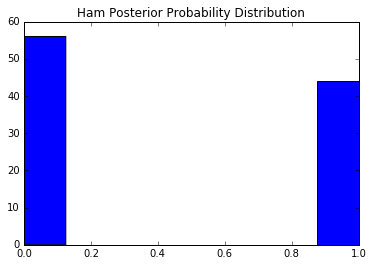

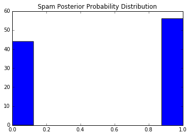

```python
%matplotlib inline
#!/usr/bin/env python

import sys
import re
import math
import numpy as np
import matplotlib.pyplot as plt
from decimal import Decimal
from collections import defaultdict

def jointProbability(hamSpamTuples):

    spamSum = 0
    hamSum = 0

    for hamSpamTuple in hamSpamTuples:
        ham = hamSpamTuple[0]
        spam = hamSpamTuple[1]
        spamSum += math.log(spam + sys.float_info.epsilon)
        hamSum += math.log(ham + sys.float_info.epsilon)

    return (hamSum, spamSum)
    #return (math.exp(hamSum),math.exp(spamSum))

modelProbs = defaultdict(tuple)

#Format: {key: (P(D|ham), P(D|spam))}
conditionalProbs = defaultdict(tuple)
totalWords = 0
spamWords = 0
hamWords = 0
posteriorSpam = []
posteriorHam = []

#Don't forget to rerun the model so that ham and spam aren't mixed up
with open("SPAM_Model_MNB.tsv") as f:
    model = f.readlines()
    for line in model:
        word, ham, spam = line.split()
        modelProbs[word] = (float(ham), float(spam))

with open("NaiveBayes/enronemail_1h.txt") as f:
    lines = f.readlines()
    for line in lines:
        cp = line.split()
        key = cp[0]
        label = int(cp[1])
        email = cp[2:]
        email = " ".join(cp[2:])
        email = re.findall(r'[a-z/\']+',email.lower())
        wordCount = len(email)
        email = [modelProbs[word] for word in email]
        email = [word if word!=() else (0,0) for word in email]
        #probs = reduce(lambda x,y : (math.exp(math.log(x[0] + sys.float_info.epsilon)+math.log(y[0] + sys.float_info.epsilon)),math.exp(math.log(x[1] + sys.float_info.epsilon)+math.log(y[1] + sys.float_info.epsilon))),email)
        #probs = (math.exp(probs[0]),math.exp(probs[1]))
        probs = jointProbability(email)
        conditionalProbs[key]=probs

        totalWords+=1
        if int(label)==1:
            spamWords+=1
        else:
            hamWords+=1

probSpam = spamWords/totalWords
probHam = hamWords/totalWords

for k, v in conditionalProbs.items():
    #Assumes that v is (condProbHam, condProbSpam)
    probDoc = probSpam*v[1]+probHam*v[0]
    probSpamCond = probSpam * v[1] / probDoc
    probHamCond = probHam * v[0] / probDoc

    #print "%s\t%s\t%s" % (k, probHamCond, probSpamCond)

    #Did some math hopefully i didn't make a big mistake
    #ab/cd = exp(ln(ab/cd)) = exp(ln(a)+ln(b)-ln(c)-ln(d)
    #P(S|D) = exp(-ln(1+exp(ln(a)+ln(b)-ln(c)-ln(d))))
    #a = P(D|H) b = P(H) c = P(D|S) d = P(S)
    #print "%s\t%s\t%s\t%s" % (v[0] ,v[1],math.log(probHam), math.log(probSpam))

    #Either zero or one
    probSpamCond = math.exp(-math.log(1+math.exp(min(500,max(-500,v[0] + math.log(probHam) - v[1] - math.log(probSpam))))))
    probHamCond = math.exp(-math.log(1+math.exp(min(500,max(-500,v[1] + math.log(probSpam) - v[0] - math.log(probHam))))))
    #print "%s\t%s\t%s" % (k, probHamCond, probSpamCond)
    posteriorSpam.append(probSpamCond)
    posteriorHam.append(probHamCond)

plt.hist(posteriorHam, bins='auto')  # plt.hist passes it's arguments to np.histogram
plt.title("Ham Posterior Probability Distribution")
plt.show()

plt.hist(posteriorSpam, bins='auto')  # plt.hist passes it's arguments to np.histogram
plt.title("Spam Posterior Probability Distribution")
plt.show()
```

The two distributions are entirely consisting of ~0 and ~1 probabilities for each document. This is not surprising considering that if a document contains a word that is not included in either the spam or ham corpus, then the probability of it occurring is zero, so the entire probability is zero. This is due to the no-smoothing approach.

## 3. HW2.4 Use Laplace plus-one smoothing

Back to Table of Contents

Repeat HW2.3 with the following modification: use Laplace plus-one smoothing.

In addition, compare the misclassifcation error rates for 2.3 versus 2.4 and explain the differences.

```python
%%bash

sudo touch NaiveBayes/mapper241.py
sudo touch NaiveBayes/reducer241.py
sudo touch NaiveBayes/combiner241.py
sudo chmod -R 777 NaiveBayes/
```

```python
%%writefile NaiveBayes/mapper241.py
#!/usr/bin/env python

import sys
import re
from collections import defaultdict

spam = defaultdict(int)
ham = defaultdict(int)
words = set()


for line in sys.stdin:
    spamOrHam = "spam" if line.split()[1]=="1" else "ham"
    for word in re.findall(r'[a-z/\']+', line.lower())[1:]:  #line.split() previously
        words.add(word)
        if spamOrHam == "spam":
            spam[word]+=1
        elif spamOrHam == "ham":
            ham[word]+=1

for word in words:
    print '%s\t%s\t%s' % (word, ham[word],spam[word])
```

```
Overwriting NaiveBayes/mapper241.py
```

```python
%%writefile NaiveBayes/reducer241.py
#!/usr/bin/env python

import sys
from collections import defaultdict

spamD = defaultdict(int)
hamD = defaultdict(int)
spamWords=0
hamWords=0
words = set()

for line in sys.stdin:
    word, ham, spam = line.split()
    spamD[word]+=float(spam)
    hamD[word]+=float(ham)
    spamWords+=float(spam)
    hamWords+=float(ham)
    words.add(word)

vocabSize = len(words)

for word in words:
    spamProb = str(0 if spamWords==0 else (float(spamD[word])+1)/(int(spamWords) + vocabSize))
    hamProb = str(0 if hamWords==0 else (float(hamD[word])+1)/(int(hamWords) + vocabSize))
    print '%s\t%s\t%s' % (word, hamProb, spamProb)
```

```
Overwriting NaiveBayes/reducer241.py
```

```python
!less NaiveBayes/chineseExample.txt | NaiveBayes/mapper241.py
!printf "dog 1 4 \n cat 3 4" | NaiveBayes/reducer241.py
!head NaiveBayes/chineseExample.txt | NaiveBayes/mapper241.py | NaiveBayes/reducer241.py #| NaiveBayes/combiner231.py
```

```
dog	0.333333333333	0.5
cat	0.666666666667	0.5
```

```python
!hdfs dfs -rm chineseExample.txt
!hdfs dfs -copyFromLocal /home/cloudera/share/NaiveBayes/chineseExample.txt
!hdfs dfs -rm -r chinese
#usr/local/Cellar/hadoop/2.6.0/libexec/share/hadoop/tools/lib
dataDir = "/home/cloudera/share/NaiveBayes"

!hadoop jar /usr/lib/hadoop-0.20-mapreduce/contrib/streaming/hadoop-streaming-2.6.0-mr1-cdh5.8.0.jar \
   -mapper /home/cloudera/share/NaiveBayes/mapper241.py \
   -reducer /home/cloudera/share/NaiveBayes/reducer241.py \
   -input chineseExample.txt \
   -output chinese  \
   -numReduceTasks 1
#--D mapreduce.job.reduces=2  depecated
#-input historical_tours.txt  file on Hadoop


#output directory on Hadoop
```

[output not shown]

[output cut: 28 more lines]

[output not shown]

```python
%%bash

sudo touch NaiveBayes/chineseModel.tsv
sudo chmod -R 777 NaiveBayes/
hdfs dfs -cat chinese/part-0000* > NaiveBayes/chineseModel.tsv
hdfs dfs -cat chinese/part-0000*
```

[output not shown]

### Hand calculations for Multinomial naive Bayes (Learning and classifiction)

- Insert hand calculations for learning a multinomial naive Bayes Classifier from the Chinese dataset
- Insert hand calculations for classifying the test document "D5" using the learnt multinomial naive Bayes Classifier from the Chinese dataset

\begin{equation} P(c) = 3/4 \\ P(!c) = 1/4 \\ P(Chinese|c) = (1+5)/(8+6) = 6/14 = 3/7 \\ P(Tokyo|c) = P(Japan|c) = (1)/(8+6) = 1/14 \\ P(Chinese|!c) = (1+1)/(3+6) = 2/9 \\ P(Tokyo|!c) = P(Japan|!c) = (1+1)/(3+6)=2/9 \\ P(Beijing|c)=P(Shanghai|c)=P(Macao|c)=(1+1)/(8+6) = 2/14 = 1/7 \\ P(Beijing|!c)=P(Shanghai|!c)=P(Macao|!c)=1/(6+3)= 1/9 \\ P(c|D5) = P(c)*P(Chinese|c)^3*P(Tokyo|c)*P(Japan|c) = 3/4 * (3/7)^3 * ( 1/(14) ) = 0.0003 \\ P(!c|D5) = P(!c)*P(Chinese|!c)^3*P(Tokyo|!c)*P(Japan|!c) = 1/4 * (2/9)^3 * 2/3 * 2/3 = 0.0001 \end{equation}

Therefore we predict that D5 is a chinese document.

###### Learnt Multinomial Naive Bayes Model WITH Smoothing

| Word | Word Class Conditional counts and probs |
| --- | --- |
| Beijing | [0.0, 1.0, 1/9, 1/7] |
| Chinese | [1.0, 5.0, 2/9, 3/7] |
| Tokyo | [1.0, 0.0, 2/9, 1/14] |
| Shanghai | [0.0, 1.0, 1/9, 1/7] |
| **ModelPrior** | [1.0, 3.0, 0.25, 0.75] |
| Japan | [1.0, 0.0, 2/9, 1/14] |
| Macao | [0.0, 1.0, 1/9, 1/7] |

```python
%%bash
#Run a mapreduce that includes the subject line.  Save the hadoop output to a regular file SPAM_Model_MNB.tsv
#Do a simple head and tail sort situation to show top 10 and bottom 10 terms alphabetically ordered
#Really this should be easy, it's just tweaking the mapper, running it, saving the model, then printing results

sudo touch NaiveBayes/mapper243.py
sudo touch NaiveBayes/reducer243.py
sudo chmod -R 777 NaiveBayes/
```

```python
%%writefile NaiveBayes/mapper243.py
#!/usr/bin/env python

import sys
import re
from collections import defaultdict

spam = defaultdict(int)
ham = defaultdict(int)
words = set()


#Modify this so that you don't count the key; key is not the same as subject line
for line in sys.stdin:
    cp = line.split()
    label = cp[1]
    email = cp[2:]
    email = " ".join(cp[2:])
    spamOrHam = "spam" if label=="1" else "ham"
    for word in re.findall(r'[a-z/\']+', email.lower()):  #line.split() previously
        words.add(word)
        if spamOrHam == "spam":
            spam[word]+=1
        elif spamOrHam == "ham":
            ham[word]+=1

for word in words:
    print '%s\t%s\t%s' % (word, ham[word],spam[word])
```

```
Overwriting NaiveBayes/mapper243.py
```

```python
%%writefile NaiveBayes/reducer243.py
#!/usr/bin/env python

import sys
from collections import defaultdict

spamD = defaultdict(int)
hamD = defaultdict(int)
spamWords=0
hamWords=0
words = set()

for line in sys.stdin:
    word, ham, spam = line.split()
    spamD[word]+=float(spam)
    hamD[word]+=float(ham)
    spamWords+=float(spam)
    hamWords+=float(ham)
    words.add(word)

vocabSize = len(words)

for word in words:
    spamProb = str(0 if spamWords==0 else (float(spamD[word])+1)/(int(spamWords) + vocabSize))
    hamProb = str(0 if hamWords==0 else (float(hamD[word])+1)/(int(hamWords) + vocabSize))
    print '%s\t%s\t%s' % (word, hamProb, spamProb)
```

```
Overwriting NaiveBayes/reducer243.py
```

```python
!hdfs dfs -rm enronemail_1h.txt
!hdfs dfs -copyFromLocal /home/cloudera/share/NaiveBayes/enronemail_1h.txt
!hdfs dfs -rm -r enron
#usr/local/Cellar/hadoop/2.6.0/libexec/share/hadoop/tools/lib
dataDir = "/home/cloudera/share/NaiveBayes"

!hadoop jar /usr/lib/hadoop-0.20-mapreduce/contrib/streaming/hadoop-streaming-2.6.0-mr1-cdh5.8.0.jar \
   -mapper /home/cloudera/share/NaiveBayes/mapper243.py \
   -reducer /home/cloudera/share/NaiveBayes/reducer243.py \
   -input enronemail_1h.txt \
   -output enron  \
   -numReduceTasks 1
#--D mapreduce.job.reduces=2  depecated
#-input historical_tours.txt  file on Hadoop


#output directory on Hadoop
```

[output not shown]

[output cut: 36 more lines]

[output not shown]

```python
%%bash

sudo touch NaiveBayes/SPAM_Model_MNB.tsv
sudo chmod -R 777 NaiveBayes/
hdfs dfs -cat enron/part-0000* > NaiveBayes/SPAM_Model_MNB.tsv
```

[output not shown]

[output not shown]

```python
%%bash

sudo chmod -R 777 NaiveBayes/
less NaiveBayes/SPAM_Model_MNB.tsv | sort -k1,1 | head -10
printf "\n"
less NaiveBayes/SPAM_Model_MNB.tsv | sort -k1,1 | tail -10
```

[output not shown]

```
sort: write failed: standard output: Broken pipe
sort: write error
```

```python
%%bash
#Run a mapreduce that includes the subject line.  Save the hadoop output to a regular file SPAM_Model_MNB.tsv
#Do a simple head and tail sort situation to show top 10 and bottom 10 terms alphabetically ordered
#Really this should be easy, it's just tweaking the mapper, running it, saving the model, then printing results

sudo touch NaiveBayes/mapper244.py
sudo touch NaiveBayes/mapper244_chinese.py
sudo touch NaiveBayes/reducer244.py
sudo chmod -R 777 NaiveBayes/
```

```python
%%writefile NaiveBayes/mapper244_chinese.py
#!/usr/bin/env python

import sys
import re
import math
from collections import defaultdict

def jointProbability(hamSpamTuples):

    spamSum = 0
    hamSum = 0

    for hamSpamTuple in hamSpamTuples:
        ham = hamSpamTuple[0]
        spam = hamSpamTuple[1]
        spamSum += math.log(spam + sys.float_info.epsilon)
        hamSum += math.log(ham + sys.float_info.epsilon)

    return (hamSum, spamSum)

modelProbs = defaultdict(tuple)
spam = defaultdict(int)
ham = defaultdict(int)
words = set()

#Don't forget to rerun the model so that ham and spam aren't mixed up
with open("chineseModel.tsv") as f:
    model = f.readlines()
    for line in model:
        word, ham, spam = line.split()
        modelProbs[word] = (float(ham), float(spam))

for line in sys.stdin:
    cp = line.split()
    key = cp[0]
    label = cp[1]
    email = cp[2:]
    email = " ".join(cp[2:])
    email = re.findall(r'[a-z/\']+',email.lower())
    numWords = len(email)
    email = [modelProbs[word] for word in email]
    email = [word if word!=() else (0,0) for word in email]
    #probs = reduce(lambda x,y : (x[0]*y[0],x[1]*y[1]),email)
    probs = jointProbability(email)
    print "%s\t%s\t%s\t%s\t%s" % (key, label, numWords, probs[0], probs[1])
```

```
Overwriting NaiveBayes/mapper244_chinese.py
```

```python
%%writefile NaiveBayes/mapper244.py
#!/usr/bin/env python

import sys
import re
import math
from collections import defaultdict

def jointProbability(hamSpamTuples):

    spamSum = 0
    hamSum = 0

    for hamSpamTuple in hamSpamTuples:
        ham = hamSpamTuple[0]
        spam = hamSpamTuple[1]
        spamSum += math.log(spam + sys.float_info.epsilon)
        hamSum += math.log(ham + sys.float_info.epsilon)

    return (hamSum, spamSum)

modelProbs = defaultdict(tuple)
spam = defaultdict(int)
ham = defaultdict(int)
words = set()

#Don't forget to rerun the model so that ham and spam aren't mixed up
with open("SPAM_Model_MNB.tsv") as f:
    model = f.readlines()
    for line in model:
        word, ham, spam = line.split()
        modelProbs[word] = (float(ham), float(spam))

for line in sys.stdin:
    cp = line.split()
    key = cp[0]
    label = cp[1]
    email = cp[2:]
    email = " ".join(cp[2:])
    email = re.findall(r'[a-z/\']+',email.lower())
    numWords = len(email)
    email = [modelProbs[word] for word in email]
    email = [word if word!=() else (0,0) for word in email]
    #probs = reduce(lambda x,y : (x[0]*y[0],x[1]*y[1]),email)
    probs = jointProbability(email)
    print "%s\t%s\t%s\t%s\t%s" % (key, label, numWords, probs[0], probs[1])
```

```
Overwriting NaiveBayes/mapper244.py
```

```python
%%writefile NaiveBayes/reducer244.py
#!/usr/bin/env python

import sys
import math
from collections import defaultdict

spamWords=0
hamWords=0
totalWords=0
lines = []

for line in sys.stdin:
    lines.append(line)
    key, label, wordCount, notImp1, notImp2 = line.split()
    totalWords+=1
    if int(label)==1:
        spamWords+=1
    else:
        hamWords+=1

spamProb = math.log(sys.float_info.epsilon + float(spamWords)/totalWords)
hamProb = math.log(sys.float_info.epsilon + float(hamWords)/totalWords)

for line in lines:
    key, label, wordCount, hamProbCond, spamProbCond = line.split()
    probs = (float(hamProbCond)+hamProb, float(spamProbCond)+spamProb)

    if probs[0]==probs[1]:
        predLabel = 1 if spamProb < hamProb else 0
    else:
        predLabel = 1 if probs[0] < probs[1] else 0

    print "%s\t%s" % (key, predLabel)
```

```
Overwriting NaiveBayes/reducer244.py
```

```python
!hdfs dfs -rm enronemail_1h.txt
!hdfs dfs -copyFromLocal /home/cloudera/share/NaiveBayes/enronemail_1h.txt
!hdfs dfs -rm -r enron
#usr/local/Cellar/hadoop/2.6.0/libexec/share/hadoop/tools/lib
dataDir = "/home/cloudera/share/NaiveBayes"

!hadoop jar /usr/lib/hadoop-0.20-mapreduce/contrib/streaming/hadoop-streaming-2.6.0-mr1-cdh5.8.0.jar \
   -mapper /home/cloudera/share/NaiveBayes/mapper244.py \
   -reducer /home/cloudera/share/NaiveBayes/reducer244.py \
   -input enronemail_1h.txt \
   -output enron  \
   -file /home/cloudera/share/NaiveBayes/SPAM_Model_MNB.tsv \
   -numReduceTasks 1
#--D mapreduce.job.reduces=2  depecated
#-input historical_tours.txt  file on Hadoop


#output directory on Hadoop
```

[output not shown]

[output cut: 36 more lines]

[output not shown]

```python
!sudo touch NaiveBayes/enronPredicted.txt
!sudo chmod -R 777 NaiveBayes/
!hdfs dfs -cat enron/part-0000*
!hdfs dfs -cat enron/part-0000* > NaiveBayes/enronPredicted.txt | head -10
```

```
0001.1999-12-10.farmer	0
0001.1999-12-10.kaminski	0
0001.2000-01-17.beck	0
0001.2000-06-06.lokay	0
0001.2001-02-07.kitchen	0
0001.2001-04-02.williams	0
0002.1999-12-13.farmer	0
0002.2001-02-07.kitchen	0
0002.2001-05-25.SA_and_HP	1
0002.2003-12-18.GP	1
0002.2004-08-01.BG	1
0003.1999-12-10.kaminski	0
0003.1999-12-14.farmer	0
0003.2000-01-17.beck	0
0003.2001-02-08.kitchen	0
0003.2003-12-18.GP	1
0003.2004-08-01.BG	1
0004.1999-12-10.kaminski	0
0004.1999-12-14.farmer	0
0004.2001-04-02.williams	0
0004.2001-06-12.SA_and_HP	1
0004.2004-08-01.BG	1
0005.1999-12-12.kaminski	0
0005.1999-12-14.farmer	0
0005.2000-06-06.lokay	0
0005.2001-02-08.kitchen	0
0005.2001-06-23.SA_and_HP	1
0005.2003-12-18.GP	1
0006.1999-12-13.kaminski	0
0006.2001-02-08.kitchen	0
0006.2001-04-03.williams	0
0006.2001-06-25.SA_and_HP	1
0006.2003-12-18.GP	1
0006.2004-08-01.BG	1
0007.1999-12-13.kaminski	0
0007.1999-12-14.farmer	0
0007.2000-01-17.beck	0
0007.2001-02-09.kitchen	0
0007.2003-12-18.GP	1
0007.2004-08-01.BG	1
```

[output cut: 45 more lines]

```
0016.1999-12-15.farmer	0
0016.2001-02-12.kitchen	0
0016.2001-07-05.SA_and_HP	1
0016.2001-07-06.SA_and_HP	1
0016.2003-12-19.GP	1
0016.2004-08-01.BG	1
0017.1999-12-14.kaminski	0
0017.2000-01-17.beck	0
0017.2001-04-03.williams	0
0017.2003-12-18.GP	1
0017.2004-08-01.BG	1
0017.2004-08-02.BG	1
0018.1999-12-14.kaminski	0
0018.2001-07-13.SA_and_HP	1
0018.2003-12-18.GP	1
```

```python
from collections import defaultdict

def accuracy(trueFile, predictFile):
    actual = defaultdict(int)
    predicted = defaultdict(int)
    matches = 0
    total = 0

    with open(trueFile) as f:
        lines = f.readlines()

        for line in lines:
            elements = line.split()
            key = elements[0]
            label = elements[1]
            actual[key]=int(label)
    f.close()

    with open(predictFile) as f:
        lines = f.readlines()

        for line in lines:
            elements = line.split()
            key = elements[0]
            label = elements[1]
            predicted[key]=int(label)

    if set(actual.keys())==set(predicted.keys()):
        for k,v in actual.items():
            if v==predicted[k]:
                matches+=1
            total+=1
        print str(float(matches)/len(actual))
    else:
        print "shit"

accuracy("NaiveBayes/enronPredicted.txt", "NaiveBayes/enronemail_1h.txt")
```

```
1.0
```

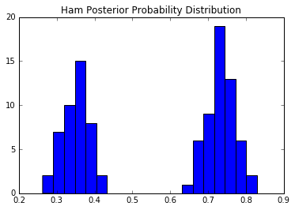

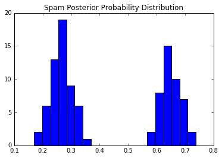

```python
%matplotlib inline
#!/usr/bin/env python

import sys
import re
import math
import numpy as np
import matplotlib.pyplot as plt
from decimal import Decimal
from collections import defaultdict

def jointProbability(hamSpamTuples):

    spamSum = 0
    hamSum = 0

    for hamSpamTuple in hamSpamTuples:
        ham = hamSpamTuple[0]
        spam = hamSpamTuple[1]
        spamSum += math.log(spam + sys.float_info.epsilon)
        hamSum += math.log(ham + sys.float_info.epsilon)

    return (hamSum, spamSum)
    #return (math.exp(hamSum),math.exp(spamSum))

modelProbs = defaultdict(tuple)

#Format: {key: (P(D|ham), P(D|spam))}
conditionalProbs = defaultdict(tuple)
totalWords = 0
spamWords = 0
hamWords = 0
posteriorSpam = []
posteriorHam = []
words = set()

#Don't forget to rerun the model so that ham and spam aren't mixed up
with open("SPAM_Model_MNB.tsv") as f:
    model = f.readlines()
    for line in model:
        word, ham, spam = line.split()
        words.add(word)
        modelProbs[word] = (float(ham), float(spam))

vocabSize = len(words)

with open("NaiveBayes/enronemail_1h.txt") as f:
    lines = f.readlines()
    for line in lines:
        cp = line.split()
        key = cp[0]
        label = int(cp[1])
        email = cp[2:]
        email = " ".join(cp[2:])
        email = re.findall(r'[a-z/\']+',email.lower())
        email = [modelProbs[word] for word in email]
        email = [word if word!=() else (0,0) for word in email]
        #probs = reduce(lambda x,y : (math.exp(math.log(x[0] + sys.float_info.epsilon)+math.log(y[0] + sys.float_info.epsilon)),math.exp(math.log(x[1] + sys.float_info.epsilon)+math.log(y[1] + sys.float_info.epsilon))),email)
        #probs = (math.exp(probs[0]),math.exp(probs[1]))
        probs = jointProbability(email)
        conditionalProbs[key]=probs

        totalWords+=1
        if int(label)==1:
            spamWords+=1
        else:
            hamWords+=1

probSpam = float(spamWords)/totalWords
probHam = float(hamWords)/totalWords

for k, v in conditionalProbs.items():
    #Assumes that v is (condProbHam, condProbSpam)
    probDoc = probSpam*v[1]+probHam*v[0]
    probSpamCond = (probSpam * v[1]) /(probDoc)
    probHamCond = (probHam * v[0]) / (probDoc)


    #print "%s\t%s\t%s" % (k, probHamCond, probSpamCond)

    #Did some math hopefully i didn't make a big mistake
    #ab/cd = exp(ln(ab/cd)) = exp(ln(a)+ln(b)-ln(c)-ln(d)
    #P(S|D) = exp(-ln(1+exp(ln(a)+ln(b)-ln(c)-ln(d))))
    #a = P(D|H) b = P(H) c = P(D|S) d = P(S)
    #print "%s\t%s\t%s\t%s" % (v[0] ,v[1],math.log(probHam), math.log(probSpam))

    #Either zero or one
    #probSpamCond = math.exp(-math.log(1+math.exp(min(500,max(-500,v[0] + math.log(probHam) - v[1] - math.log(probSpam))))))
    #probHamCond = math.exp(-math.log(1+math.exp(min(500,max(-500,v[1] + math.log(probSpam) - v[0] - math.log(probHam))))))
    #print "%s\t%s\t%s" % (k, probHamCond, probSpamCond)
    posteriorSpam.append(probSpamCond)
    posteriorHam.append(probHamCond)

plt.hist(posteriorHam, bins=20)  # plt.hist passes it's arguments to np.histogram
plt.title("Ham Posterior Probability Distribution")
plt.show()

plt.hist(posteriorSpam, bins=20)  # plt.hist passes it's arguments to np.histogram
plt.title("Spam Posterior Probability Distribution")
plt.show()
```

It would seem that there isn't much middle ground for the distribution of the SPAM and HAM conditional probabilities; they're either mostly likely or mostly unlikely.

Regarding the two classification accuracies, we see that the model without smoothing has 67% accuracy whereas the one with laplace smoothing has %100 accuracy. The accuracy of the smoothed naive bayes shouldn't be surprising because we're using our training set as our test set also, so the model should contour to this data precisely. The main reason for the improvement is that without smoothing a conditional probability P(Doc|SPAM) may have an email with words that do not occur within the class, and as such that words individual probability would be zero, and this would deem the entire conditional probability zero. With Laplace smoothing, every probability for an individual word occurrence has at least some small probability (1/(vocabularySize) to be precise).

## 3. HW2.5 Ignore rare words

Back to Table of Contents

Repeat HW2.4. This time when modeling and classification ignore tokens with a frequency of less than three (3) in the training set. How does it affect the misclassifcation error of learnt naive multinomial Bayesian Classifier on the training dataset. Report the error and the change in error.

**HINT:** ignore tokens with a frequency of less than three (3). Think of this as a preprocessing step. How many mapreduce jobs do you need to solve thus homework?

```python
%%bash

sudo touch NaiveBayes/mapper251.py
sudo touch NaiveBayes/reducer251.py
sudo touch NaiveBayes/combiner251.py
sudo chmod -R 777 NaiveBayes/
```

```python
%%writefile NaiveBayes/mapper251.py
#!/usr/bin/env python

import sys
import re
from collections import defaultdict

spam = defaultdict(int)
ham = defaultdict(int)
words = set()


for line in sys.stdin:
    spamOrHam = "spam" if line.split()[1]=="1" else "ham"
    for word in re.findall(r'[a-z/\']+', line.lower())[1:]:  #line.split() previously
        words.add(word)
        if spamOrHam == "spam":
            spam[word]+=1
        elif spamOrHam == "ham":
            ham[word]+=1

for word in words:
    print '%s\t%s\t%s' % (word, ham[word],spam[word])
```

```
Overwriting NaiveBayes/mapper251.py
```

```python
%%writefile NaiveBayes/reducer251.py
#!/usr/bin/env python

import sys
from collections import defaultdict

spamD = defaultdict(int)
hamD = defaultdict(int)
spamWords=0
hamWords=0
allWords = set()
filteredWords = set()

for line in sys.stdin:
    word, ham, spam = line.split()
    spamD[word]+=float(spam)
    hamD[word]+=float(ham)
    allWords.add(word)

#Smoothing parameter should count the vocabSize after filtering
for word in allWords:
    if hamD[word]+spamD[word] >= 3:
        filteredWords.add(word)
        spamWords+=spamD[word]
        hamWords+=hamD[word]

vocabSize = len(filteredWords)

for word in filteredWords:
    if hamD[word]+spamD[word] >= 3:
        spamProb = str(0 if spamWords==0 else (float(spamD[word])+1)/(int(spamWords) + vocabSize))
        hamProb = str(0 if hamWords==0 else (float(hamD[word])+1)/(int(hamWords) + vocabSize))
        print '%s\t%s\t%s' % (word, hamProb, spamProb)
```

```
Overwriting NaiveBayes/reducer251.py
```

```python
!less NaiveBayes/chineseExample.txt | NaiveBayes/mapper251.py
!printf "\n"
!printf "dog 1 4 \n cat 3 4" | NaiveBayes/reducer251.py
!printf "\n"
!head NaiveBayes/chineseExample.txt | NaiveBayes/mapper251.py | NaiveBayes/reducer251.py #| NaiveBayes/combiner231.py
```

```
beijing	0	1
chinese	1	5
tokyo	1	0
shanghai	0	1
japan	1	0
macao	0	1

dog	0.333333333333	0.5
cat	0.666666666667	0.5

chinese	1.0	1.0
```

```python
!hdfs dfs -rm chineseExample.txt
!hdfs dfs -copyFromLocal /home/cloudera/share/NaiveBayes/chineseExample.txt
!hdfs dfs -rm -r chinese
#usr/local/Cellar/hadoop/2.6.0/libexec/share/hadoop/tools/lib
dataDir = "/home/cloudera/share/NaiveBayes"

!hadoop jar /usr/lib/hadoop-0.20-mapreduce/contrib/streaming/hadoop-streaming-2.6.0-mr1-cdh5.8.0.jar \
   -mapper /home/cloudera/share/NaiveBayes/mapper251.py \
   -reducer /home/cloudera/share/NaiveBayes/reducer251.py \
   -input chineseExample.txt \
   -output chinese  \
   -numReduceTasks 1
#--D mapreduce.job.reduces=2  depecated
#-input historical_tours.txt  file on Hadoop


#output directory on Hadoop
```

[output not shown]

[output cut: 35 more lines]

[output not shown]

```python
%%bash

sudo touch NaiveBayes/chineseModel.tsv
sudo chmod -R 777 NaiveBayes/
hdfs dfs -cat chinese/part-0000* > NaiveBayes/chineseModel.tsv
hdfs dfs -cat chinese/part-0000*
```

```
chinese	1.0	1.0
```

### Hand calculations for Multinomial naive Bayes (Learning and classifiction)

After filtering the chinese example only contains the word "Chinese," so things get a little trivial.

Therefore we predict that D5 is not a chinese document.

###### Learnt Multinomial Naive Bayes Model WITH Smoothing

| Word | Word Class Conditional counts and probs |
| --- | --- |
| Beijing | [0.0, 0, 1/6, 1/2] |
| Chinese | [1.0, 5.0, 1, 1] |
| Tokyo | [0, 0.0, 1/6, 1/2] |
| Shanghai | [0.0, 0, 1/6, 1/2] |
| **ModelPrior** | [1.0, 3.0, 0.25, 0.75] |
| Japan | [0, 0.0, 1/6, 1/2] |
| Macao | [0.0, 0, 1/6, 1/2] |

```python
%%bash
#Run a mapreduce that includes the subject line.  Save the hadoop output to a regular file SPAM_Model_MNB.tsv
#Do a simple head and tail sort situation to show top 10 and bottom 10 terms alphabetically ordered
#Really this should be easy, it's just tweaking the mapper, running it, saving the model, then printing results

sudo touch NaiveBayes/mapper253.py
sudo touch NaiveBayes/reducer253.py
sudo chmod -R 777 NaiveBayes/
```

```python
%%writefile NaiveBayes/mapper253.py
#!/usr/bin/env python

import sys
import re
from collections import defaultdict

spam = defaultdict(int)
ham = defaultdict(int)
words = set()


#Modify this so that you don't count the key; key is not the same as subject line
for line in sys.stdin:
    cp = line.split()
    label = cp[1]
    email = cp[2:]
    email = " ".join(cp[2:])
    spamOrHam = "spam" if label=="1" else "ham"
    for word in re.findall(r'[a-z/\']+', email.lower()):  #line.split() previously
        words.add(word)
        if spamOrHam == "spam":
            spam[word]+=1
        elif spamOrHam == "ham":
            ham[word]+=1

for word in words:
    print '%s\t%s\t%s' % (word, ham[word],spam[word])
```

```
Overwriting NaiveBayes/mapper253.py
```

```python
%%writefile NaiveBayes/reducer253.py
#!/usr/bin/env python

import sys
from collections import defaultdict

spamD = defaultdict(int)
hamD = defaultdict(int)
spamWords=0
hamWords=0
allWords = set()
filteredWords = set()

for line in sys.stdin:
    word, ham, spam = line.split()
    spamD[word]+=float(spam)
    hamD[word]+=float(ham)
    allWords.add(word)

#Smoothing parameter should count the vocabSize after filtering
for word in allWords:
    if hamD[word]+spamD[word] >= 3:
        filteredWords.add(word)
        spamWords+=spamD[word]
        hamWords+=hamD[word]

vocabSize = len(filteredWords)

for word in filteredWords:
    if hamD[word]+spamD[word] >= 3:
        spamProb = str(0 if spamWords==0 else (float(spamD[word])+1)/(int(spamWords) + vocabSize))
        hamProb = str(0 if hamWords==0 else (float(hamD[word])+1)/(int(hamWords) + vocabSize))
        print '%s\t%s\t%s' % (word, hamProb, spamProb)
```

```
Overwriting NaiveBayes/reducer253.py
```

```python
!hdfs dfs -rm enronemail_1h.txt
!hdfs dfs -copyFromLocal /home/cloudera/share/NaiveBayes/enronemail_1h.txt
!hdfs dfs -rm -r enron
#usr/local/Cellar/hadoop/2.6.0/libexec/share/hadoop/tools/lib
dataDir = "/home/cloudera/share/NaiveBayes"

!hadoop jar /usr/lib/hadoop-0.20-mapreduce/contrib/streaming/hadoop-streaming-2.6.0-mr1-cdh5.8.0.jar \
   -mapper /home/cloudera/share/NaiveBayes/mapper253.py \
   -reducer /home/cloudera/share/NaiveBayes/reducer253.py \
   -input enronemail_1h.txt \
   -output enron  \
   -numReduceTasks 1
#--D mapreduce.job.reduces=2  depecated
#-input historical_tours.txt  file on Hadoop


#output directory on Hadoop
```

[output not shown]

[output cut: 27 more lines]

[output not shown]

```python
%%bash

sudo touch NaiveBayes/SPAM_Model_MNB.tsv
sudo chmod -R 777 NaiveBayes/
hdfs dfs -cat enron/part-0000* > NaiveBayes/SPAM_Model_MNB.tsv
```

```python
%%bash

sudo chmod -R 777 NaiveBayes/
less NaiveBayes/SPAM_Model_MNB.tsv | sort -k1,1 | head -10
printf "\n"
less NaiveBayes/SPAM_Model_MNB.tsv | sort -k1,1 | tail -10
```

```
/	0.0117422798323	0.00111685868798
//	0.000152497140679	0.00376205031742
'	0.000304994281357	0.000176346108629
a	0.0150209683568	0.0203385845286
ab	0.000457491422036	5.87820362097e-05
able	0.000304994281357	0.000705384434517
about	0.000762485703393	0.00258640959323
above	0.000304994281357	0.000529038325888
accept	7.62485703393e-05	0.000235128144839
access	0.000228745711018	0.000646602398307

you	0.00770110560427	0.0196332000941
you'll	7.62485703393e-05	0.000352692217258
your	0.00297369424323	0.0210439689631
yours	7.62485703393e-05	0.000235128144839
yourself	7.62485703393e-05	0.000705384434517
you've	7.62485703393e-05	0.000293910181049
zadorozhny/hou/ect	0.000381242851697	5.87820362097e-05
zero	0.000304994281357	0.000117564072419
zesto	7.62485703393e-05	0.000646602398307
zimin	0.000457491422036	5.87820362097e-05
```

```
sort: write failed: standard output: Broken pipe
sort: write error
```

```python
%%bash
#Run a mapreduce that includes the subject line.  Save the hadoop output to a regular file SPAM_Model_MNB.tsv
#Do a simple head and tail sort situation to show top 10 and bottom 10 terms alphabetically ordered
#Really this should be easy, it's just tweaking the mapper, running it, saving the model, then printing results

sudo touch NaiveBayes/mapper254.py
sudo touch NaiveBayes/reducer254.py
sudo chmod -R 777 NaiveBayes/
```

```python
%%writefile NaiveBayes/mapper254.py
#!/usr/bin/env python

import sys
import re
import math
from collections import defaultdict

def jointProbability(hamSpamTuples):

    spamSum = 0
    hamSum = 0

    for hamSpamTuple in hamSpamTuples:
        ham = hamSpamTuple[0]
        spam = hamSpamTuple[1]
        spamSum += math.log(spam + sys.float_info.epsilon)
        hamSum += math.log(ham + sys.float_info.epsilon)

    return (hamSum, spamSum)

modelProbs = defaultdict(tuple)
spam = defaultdict(int)
ham = defaultdict(int)
words = set()

#Don't forget to rerun the model so that ham and spam aren't mixed up
with open("SPAM_Model_MNB.tsv") as f:
    model = f.readlines()
    for line in model:
        word, ham, spam = line.split()
        modelProbs[word] = (float(ham), float(spam))
        #model only contains words that occur >=3 times
        words.add(word)

for line in sys.stdin:
    cp = line.split()
    key = cp[0]
    label = cp[1]
    email = cp[2:]
    email = " ".join(cp[2:])
    email = re.findall(r'[a-z/\']+',email.lower())
    #This is the filtering step, we just don't measure P(word) if wordOccur<3
    email = [word for word in email if word in words]
    numWords = len(email)
    email = [modelProbs[word] for word in email]
    email = [word if word!=() else (0,0) for word in email]
    #probs = reduce(lambda x,y : (x[0]*y[0],x[1]*y[1]),email)
    probs = jointProbability(email)
    print "%s\t%s\t%s\t%s\t%s" % (key, label, numWords, probs[0], probs[1])
```

```
Overwriting NaiveBayes/mapper254.py
```

```python
%%writefile NaiveBayes/reducer254.py
#!/usr/bin/env python

import sys
import math
from collections import defaultdict

spamWords=0
hamWords=0
totalWords=0
lines = []

for line in sys.stdin:
    lines.append(line)
    key, label, wordCount, notImp1, notImp2 = line.split()
    totalWords+=1
    if int(label)==1:
        spamWords+=1
    else:
        hamWords+=1

spamProb = math.log(sys.float_info.epsilon + float(spamWords)/totalWords)
hamProb = math.log(sys.float_info.epsilon + float(hamWords)/totalWords)

for line in lines:
    key, label, wordCount, hamProbCond, spamProbCond = line.split()
    probs = (float(hamProbCond)+hamProb, float(spamProbCond)+spamProb)

    if probs[0]==probs[1]:
        predLabel = 1 if spamProb < hamProb else 0
    else:
        predLabel = 1 if probs[0] < probs[1] else 0

    print "%s\t%s" % (key, predLabel)
```

```
Overwriting NaiveBayes/reducer254.py
```

```python
!hdfs dfs -rm enronemail_1h.txt
!hdfs dfs -copyFromLocal /home/cloudera/share/NaiveBayes/enronemail_1h.txt
!hdfs dfs -rm -r enron
#usr/local/Cellar/hadoop/2.6.0/libexec/share/hadoop/tools/lib
dataDir = "/home/cloudera/share/NaiveBayes"

!hadoop jar /usr/lib/hadoop-0.20-mapreduce/contrib/streaming/hadoop-streaming-2.6.0-mr1-cdh5.8.0.jar \
   -mapper /home/cloudera/share/NaiveBayes/mapper254.py \
   -reducer /home/cloudera/share/NaiveBayes/reducer254.py \
   -input enronemail_1h.txt \
   -output enron  \
   -file /home/cloudera/share/NaiveBayes/SPAM_Model_MNB.tsv \
   -numReduceTasks 1
#--D mapreduce.job.reduces=2  depecated
#-input historical_tours.txt  file on Hadoop


#output directory on Hadoop
```

[output not shown]

[output cut: 44 more lines]

[output not shown]

```python
!sudo touch NaiveBayes/enronPredicted.txt
!sudo chmod -R 777 NaiveBayes/
!hdfs dfs -cat enron/part-0000* > NaiveBayes/enronPredicted.txt
!hdfs dfs -cat enron/part-0000* | head -10
```

```
0001.1999-12-10.farmer	0
0001.1999-12-10.kaminski	0
0001.2000-01-17.beck	0
0001.2000-06-06.lokay	0
0001.2001-02-07.kitchen	0
0001.2001-04-02.williams	0
0002.1999-12-13.farmer	0
0002.2001-02-07.kitchen	0
0002.2001-05-25.SA_and_HP	1
0002.2003-12-18.GP	1
```

```python
from collections import defaultdict

def accuracy(trueFile, predictFile):
    actual = defaultdict(int)
    predicted = defaultdict(int)
    matches = 0
    total = 0

    with open(trueFile) as f:
        lines = f.readlines()

        for line in lines:
            elements = line.split()
            key = elements[0]
            label = elements[1]
            actual[key]=int(label)
    f.close()

    with open(predictFile) as f:
        lines = f.readlines()

        for line in lines:
            elements = line.split()
            key = elements[0]
            label = elements[1]
            predicted[key]=int(label)

    if set(actual.keys())==set(predicted.keys()):
        for k,v in actual.items():
            if v==predicted[k]:
                matches+=1
            total+=1
        print str(float(matches)/len(actual))
    else:
        print "shit"

#Modify this to also compute accuracy and precision
accuracy("NaiveBayes/enronPredicted.txt", "NaiveBayes/enronemail_1h.txt")
```

```
0.98
```

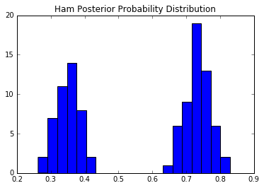

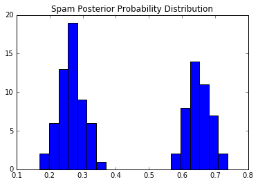

```python
%matplotlib inline
#!/usr/bin/env python

import sys
import re
import math
import numpy as np
import matplotlib.pyplot as plt
from decimal import Decimal
from collections import defaultdict

def jointProbability(hamSpamTuples):

    spamSum = 0
    hamSum = 0

    for hamSpamTuple in hamSpamTuples:
        ham = hamSpamTuple[0]
        spam = hamSpamTuple[1]
        spamSum += math.log(spam + sys.float_info.epsilon)
        hamSum += math.log(ham + sys.float_info.epsilon)

    return (hamSum, spamSum)
    #return (math.exp(hamSum),math.exp(spamSum))

modelProbs = defaultdict(tuple)

#Format: {key: (P(D|ham), P(D|spam))}
conditionalProbs = defaultdict(tuple)
totalWords = 0
spamWords = 0
hamWords = 0
posteriorSpam = []
posteriorHam = []
words = set()

#Don't forget to rerun the model so that ham and spam aren't mixed up
with open("SPAM_Model_MNB.tsv") as f:
    model = f.readlines()
    for line in model:
        word, ham, spam = line.split()
        words.add(word)
        modelProbs[word] = (float(ham), float(spam))

vocabSize = len(words)

with open("NaiveBayes/enronemail_1h.txt") as f:
    lines = f.readlines()
    for line in lines:
        cp = line.split()
        key = cp[0]
        label = int(cp[1])
        email = cp[2:]
        email = " ".join(cp[2:])
        email = re.findall(r'[a-z/\']+',email.lower())
        #This is the filtering step, we just don't measure P(word) if wordOccur<3
        email = [word for word in email if word in words]
        email = [modelProbs[word] for word in email]
        email = [word if word!=() else (0,0) for word in email]
        #probs = reduce(lambda x,y : (math.exp(math.log(x[0] + sys.float_info.epsilon)+math.log(y[0] + sys.float_info.epsilon)),math.exp(math.log(x[1] + sys.float_info.epsilon)+math.log(y[1] + sys.float_info.epsilon))),email)
        #probs = (math.exp(probs[0]),math.exp(probs[1]))
        probs = jointProbability(email)
        conditionalProbs[key]=probs

        totalWords+=1
        if int(label)==1:
            spamWords+=1
        else:
            hamWords+=1

probSpam = float(spamWords)/totalWords
probHam = float(hamWords)/totalWords

for k, v in conditionalProbs.items():
    #Assumes that v is (condProbHam, condProbSpam)
    probDoc = probSpam*v[1]+probHam*v[0]
    probSpamCond = (probSpam * v[1]) /(probDoc)
    probHamCond = (probHam * v[0]) / (probDoc)


    #print "%s\t%s\t%s" % (k, probHamCond, probSpamCond)

    #Did some math hopefully i didn't make a big mistake
    #ab/cd = exp(ln(ab/cd)) = exp(ln(a)+ln(b)-ln(c)-ln(d)
    #P(S|D) = exp(-ln(1+exp(ln(a)+ln(b)-ln(c)-ln(d))))
    #a = P(D|H) b = P(H) c = P(D|S) d = P(S)
    #print "%s\t%s\t%s\t%s" % (v[0] ,v[1],math.log(probHam), math.log(probSpam))

    #Either zero or one
    #probSpamCond = math.exp(-math.log(1+math.exp(min(500,max(-500,v[0] + math.log(probHam) - v[1] - math.log(probSpam))))))
    #probHamCond = math.exp(-math.log(1+math.exp(min(500,max(-500,v[1] + math.log(probSpam) - v[0] - math.log(probHam))))))
    #print "%s\t%s\t%s" % (k, probHamCond, probSpamCond)
    posteriorSpam.append(probSpamCond)
    posteriorHam.append(probHamCond)

plt.hist(posteriorHam, bins=20)  # plt.hist passes it's arguments to np.histogram
plt.title("Ham Posterior Probability Distribution")
plt.show()

plt.hist(posteriorSpam, bins=20)  # plt.hist passes it's arguments to np.histogram
plt.title("Spam Posterior Probability Distribution")
plt.show()
```

Oddly this model performed slightly worse than the one with just Laplace smoothing. That said, the Laplace smoothing model had 0% misclassification error, which you can't beat. This model had 2% classification error, which is a change of 2% from the former model. I suspect that there may be a handful of emails where the omission of rare words tipped the scales in one direction, thus causing misclassifications in a few instances.

## 3. HW2.6 Benchmark your code with the Python SciKit-Learn

Back to Table of Contents

HW2.6 Benchmark your code with the Python SciKit-Learn implementation of the multinomial Naive Bayes algorithm

It always a good idea to benchmark your solutions against publicly available libraries/frameworks such as SciKit-Learn, the Machine Learning toolkit available in Python. In this exercise, we benchmark ourselves against the SciKit-Learn implementation of multinomial Naive Bayes. For more information on this implementation see: http://scikit-learn.org/stable/modules/naive_bayes.html more

In this exercise, please complete the following tasks:

- Run the Multinomial Naive Bayes algorithm (using default settings) from SciKit-Learn over the same training data used in HW2.5 and report the misclassification error (please note some data preparation might be needed to get the Multinomial Naive Bayes algorithm from SkiKit-Learn to run over this dataset)
- Prepare a table to present your results, where rows correspond to approach used (SkiKit-Learn versus your Hadoop implementation) and the column presents the training misclassification error
- Explain/justify any differences in terms of training error rates over the dataset in HW2.5 between your Multinomial Naive Bayes implementation (in Map Reduce) versus the Multinomial Naive Bayes implementation in SciKit-Learn

```python
import numpy as np
import matplotlib.pyplot as plt
import math
from sklearn.naive_bayes import BernoulliNB
from sklearn.naive_bayes import MultinomialNB
from sklearn.feature_extraction.text import *
from sklearn.metrics import confusion_matrix
from sklearn import metrics
from sklearn.metrics import classification_report

emails = []
train_data = []
train_labels = []

with open("NaiveBayes/enronemail_1h.txt") as f:
    lines = f.readlines()
    for line in lines:
        cp = line.split()
        label = cp[1]
        train_labels.append(label)
        email = cp[2:]
        email = " ".join(cp[2:])
        email = re.findall(r'[a-z/\']+',email.lower())
        email = " ".join(email)
        emails.append(email)

#Need to transform the word occurrence into matrix form
vect = CountVectorizer()
x = vect.fit_transform(emails)
train_trans = vect.transform(emails)
train_labels = np.array(train_labels)
bern=BernoulliNB()
bern.fit(x, train_labels)
pred=bern.predict(train_trans)
accuracy = np.mean(pred==train_labels)
print "Sklearn bernoulli naive bayes had " + str(100*accuracy) + "% accuracy"
print confusion_matrix(train_labels,pred)
print classification_report(train_labels, pred)
```

```
Sklearn bernoulli naive bayes had 78.0% accuracy
[[56  0]
 [22 22]]
             precision    recall  f1-score   support

          0       0.72      1.00      0.84        56
          1       1.00      0.50      0.67        44

avg / total       0.84      0.78      0.76       100
```

[output not shown]

Back to Table of Contents

## ------- END OF HOWEWORK --------